# Exemplos de uso

### Gerando novas imagens MNIST com GANs e Keras

Vasilev et al (2019) apresentam o passo a passo para gerar novas imagens a partir da base de dados MNIST usando Keras.

Para começar, vamos importar as bibliotecas necessárias:

*Importando bibliotecas matplotlib, numpy e keras*

```python
import matplotlib.pyplot as plt
import numpy as np
from keras.datasets import mnist
from keras.layers import BatchNormalization, Input, Dense, Reshape, Flatten
from keras.layers.advanced_activations import LeakyReLU
from keras.models import Sequential, Model
from keras.optimizers import Adam
```

Em seguida, vamos implementar a função build_generator, que é a rede geradora. No exemplo apresentado pelo autor, ele utiliza uma rede totalmente conectada como gerador:

*Função de rede geratória*

```python
def build_generator(latent_dim: int):
    """
    Build discriminator network
    :param latent_dim: latent vector size
    """

    model = Sequential([
        Dense(128, input_dim=latent_dim),
        LeakyReLU(alpha=0.2),
        BatchNormalization(momentum=0.8),
        Dense(256),
        LeakyReLU(alpha=0.2),
        BatchNormalization(momentum=0.8),
        Dense(512),
        LeakyReLU(alpha=0.2),
        BatchNormalization(momentum=0.8),
        Dense(np.prod((28, 28, 1)), activation='tanh'),
        # reshape to MNIST image size
        Reshape((28, 28, 1))
    ])

    model.summary()

    # the latent input vector z
    z = Input(shape=(latent_dim,))
    generated = model(z)

    # build model from the input and output
    return Model(z, generated)
```

Com a rede geradora criada, é hora de construir a rede discriminadora.

Novamente, essa será uma rede totalmente conectada simples:

*Função de rede discriminadora*

```python
def build_discriminator():
    """
    Build discriminator network
    """

    model = Sequential([
        Flatten(input_shape=(28, 28, 1)),
        Dense(256),
        LeakyReLU(alpha=0.2),
        Dense(128),
        LeakyReLU(alpha=0.2),
        Dense(1, activation='sigmoid'),
    ], name='discriminator')

    model.summary()

    image = Input(shape=(28, 28, 1))
    output = model(image)

    return Model(image, output)
```

Após a implementação das redes geradora e discriminadora,

é hora de implementar a função de treinamento:

### Função de treinamento

```python
def train(generator, discriminator, combined, steps, batch_size):
    """
    Train the GAN system
    :param generator: generator
    :param discriminator: discriminator
    :param combined: stacked generator and discriminator
    we'll use the combined network when we train the generator
    :param steps: number of alternating steps for training
    :param batch_size: size of the minibatch
    """

    # Carregando a base de dados
    (x_train, _), _ = mnist.load_data()

    # Reajustar a escala para um intervalo entre [-1, 1]
    x_train = (x_train.astype(np.float32) - 127.5) / 127.5
    x_train = np.expand_dims(x_train, axis=-1)

    # Verdades para o Discriminador
    real = np.ones((batch_size, 1))
    fake = np.zeros((batch_size, 1))

    latent_dim = generator.input_shape[1]

    for step in range(steps):
        # Treinando o discriminador

        # Selecione um conjunto aleatório de imagens reais
        real_images = x_train[np.random.randint(0, x_train.shape[0], batch_size)]

        # Pacote conjunto de valores (ruídos)
        noise = np.random.normal(0, 1, (batch_size, latent_dim))

        # Gerando um conjunto de novas imagens
        generated_images = generator.predict(noise)

        # Treinando o discriminador
        discriminator_real_loss = discriminator.train_on_batch(real_images, real)
        discriminator_fake_loss = discriminator.train_on_batch(generated_images, fake)
        discriminator_loss = 0.5 * np.add(discriminator_real_loss, discriminator_fake_loss)

        # Treinando o gerador
        # Vetor Z de valores latentes aleatórios
        noise = np.random.normal(0, 1, (batch_size, latent_dim))

        # Treinando o gerador
        # Observe que usamos os rótulos “válidos” para as imagens
        # geradas para tentar maximizar o custo do discriminador
        generator_loss = combined.train_on_batch(noise, real)

       # Mostrando o progresso
        print("%d [Discriminator loss: %.4f%%, acc.: %.2f%%] [Generator loss: %.4f%%]" %
              (step, discriminator_loss[0], 100 * discriminator_loss[1], generator_loss))
```

O próximo passo será gerar uma função comum para mostrar algumas das imagens geradas após a fase de treinamento, chamaremos essa função de plot_generated_images.

Essa função será criada da seguinte forma:

i. vamos criar um grid de tamanho nxn;

ii. vamos criar um vetor latente de valores aleatórios de tamanho nxn para cada imagem gerada;

iii. vamos gerar as imagens e colocá-las em cada célula do grid;

iv. vamos mostrar o resultado:

### Função de plotamento do resultado

```python
def plot_generated_images(generator):
    """
    Display a nxn 2D manifold of digits
    :param generator: the generator
    """
    n = 10
    digit_size = 28

    # Grande matriz contendo todas as imagens
    figure = np.zeros((digit_size * n, digit_size * n))

    latent_dim = generator.input_shape[1]

    # Distribuição aleatória dos valores latentes n*n
    noise = np.random.normal(0, 1, (n * n, latent_dim))

    # Gerando as imagens
    generated_images = generator.predict(noise)

    # Preenchendo a grande matriz com as imagens
    for i in range(n):
        for j in range(n):
            slice_i = slice(i * digit_size, (i + 1) * digit_size)
            slice_j = slice(j * digit_size, (j + 1) * digit_size)
            figure[slice_i, slice_j] = np.reshape(generated_images[i * n + j], (28, 28))

    # Mostrando os resultados
    plt.figure(figsize=(6, 5))
    plt.axis('off')
    plt.imshow(figure, cmap='Greys_r')
    plt.show()
```

O último passo será montar os construtores do gerador, do discriminador, e agregar ambos na rede.

Rodar o treinamento com 15.000 passos usando um otimizador ADAM, e mostrar os resultados ao final:

```
Model: "discriminator"
_________________________________________________________________
Layer (type)                 Output Shape              Param #
=================================================================
flatten_1 (Flatten)          (None, 784)               0
_________________________________________________________________
dense_1 (Dense)              (None, 256)               200960
_________________________________________________________________
leaky_re_lu_1 (LeakyReLU)    (None, 256)               0
_________________________________________________________________
dense_2 (Dense)              (None, 128)               32896
_________________________________________________________________
leaky_re_lu_2 (LeakyReLU)    (None, 128)               0
_________________________________________________________________
dense_3 (Dense)              (None, 1)                 129
=================================================================
Total params: 233,985
Trainable params: 233,985
Non-trainable params: 0
_________________________________________________________________
Model: "sequential_1"
_________________________________________________________________
Layer (type)                 Output Shape              Param #
=================================================================
dense_4 (Dense)              (None, 128)               8320
_________________________________________________________________
leaky_re_lu_3 (LeakyReLU)    (None, 128)               0
_________________________________________________________________
batch_normalization_1 (Batch (None, 128)               512
_________________________________________________________________
dense_5 (Dense)              (None, 256)               33024
_________________________________________________________________
leaky_re_lu_4 (LeakyReLU)    (None, 256)               0
_________________________________________________________________
batch_normalization_2 (Batch (None, 256)               1024
_________________________________________________________________
dense_6 (Dense)              (None, 512)               131584
_________________________________________________________________
leaky_re_lu_5 (LeakyReLU)    (None, 512)               0
_________________________________________________________________
batch_normalization_3 (Batch (None, 512)               2048
_________________________________________________________________
dense_7 (Dense)              (None, 784)               402192
_________________________________________________________________
reshape_1 (Reshape)          (None, 28, 28, 1)         0
=================================================================
Total params: 578,704
Trainable params: 576,912
Non-trainable params: 1,792
_________________________________________________________________
```

```
0 [Discriminator loss: 0.7547%, acc.: 33.98%] [Generator loss: 0.7561%]
1 [Discriminator loss: 0.4300%, acc.: 68.36%] [Generator loss: 0.6817%]
2 [Discriminator loss: 0.3848%, acc.: 71.48%] [Generator loss: 0.6661%]
3 [Discriminator loss: 0.3690%, acc.: 72.66%] [Generator loss: 0.6665%]
```

```
4 [Discriminator loss: 0.3669%, acc.: 76.17%] [Generator loss: 0.6534%]
5 [Discriminator loss: 0.3613%, acc.: 75.78%] [Generator loss: 0.6655%]
6 [Discriminator loss: 0.3578%, acc.: 75.00%] [Generator loss: 0.7118%]
7 [Discriminator loss: 0.3516%, acc.: 76.95%] [Generator loss: 0.6925%]
8 [Discriminator loss: 0.3342%, acc.: 81.64%] [Generator loss: 0.7456%]
9 [Discriminator loss: 0.3271%, acc.: 83.20%] [Generator loss: 0.7867%]
10 [Discriminator loss: 0.3147%, acc.: 87.89%] [Generator loss: 0.8320%]
11 [Discriminator loss: 0.3023%, acc.: 87.11%] [Generator loss: 0.8736%]
12 [Discriminator loss: 0.3063%, acc.: 85.94%] [Generator loss: 0.9063%]
13 [Discriminator loss: 0.2812%, acc.: 92.58%] [Generator loss: 0.9492%]
14 [Discriminator loss: 0.2715%, acc.: 91.80%] [Generator loss: 0.9878%]
15 [Discriminator loss: 0.2605%, acc.: 92.97%] [Generator loss: 1.0016%]
16 [Discriminator loss: 0.2410%, acc.: 94.14%] [Generator loss: 1.0934%]
17 [Discriminator loss: 0.2423%, acc.: 93.75%] [Generator loss: 1.1593%]
18 [Discriminator loss: 0.2278%, acc.: 96.88%] [Generator loss: 1.1644%]
```

[output cut: 14981 more lines]

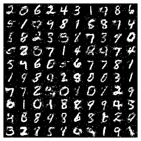

```python
if __name__ == '__main__':
    latent_dim = 64

    # Construir e compilar o discriminador
    discriminator = build_discriminator()
    discriminator.compile(loss='binary_crossentropy',
                          optimizer=Adam(lr=0.0002, beta_1=0.5),
                          metrics=['accuracy'])

    # Construir o gerador
    generator = build_generator(latent_dim)

    # Entrada z do gerador
    z = Input(shape=(latent_dim,))
    generated_image = generator(z)

    # Apenas treine o gerador para o modelo combinado
    discriminator.trainable = False

    # O gerador recebe as imagens geradas como entrada e determina sua validade
    real_or_fake = discriminator(generated_image)

    # Empilhe o gerador e o discriminador em um modelo combinado
    # Treine o gerador para enganar o discriminador
    combined = Model(z, real_or_fake)
    combined.compile(loss='binary_crossentropy',
                     optimizer=Adam(lr=0.0002, beta_1=0.5))

    # Treine o Sistema GAN
    train(generator=generator,
          discriminator=discriminator,
          combined=combined,
          steps=15000,
          batch_size=128)

    # Mostre aleatoriamente algumas imagens geradas
    plot_generated_images(generator)
```